# Habenula Atlas Project

[figure not shown]

Welcome to the Habenula Atlas project! Here you will find all code used to analyze the data generated as part of our manuscript, which is currently preprinted [here](https://doi.org/10.64898/2026.09.30.755667).

- [10x Genomics **Visium**](https://www.10xgenomics.com/products/spatial-gene-expression)
- [10x Genomics **Chromium** (snATAC + snRNA-seq)](https://www.10xgenomics.com/platforms/chromium/product-family)
- [10x Genomics **Visium HD**](https://www.10xgenomics.com/products/hd-wt-panel-gene-expression)

This work was a joint effort by the [Keri Martinowich](https://www.libd.org/team/keri-martinowich-phd/), [Leonardo Collado-Torres](http://lcolladotor.github.io/), and [Kristen Maynard](https://www.libd.org/team/kristen-maynard-phd/) teams at the [Lieber Institute for Brain Development](https://www.libd.org) as well as [Brion Maher](https://publichealth.jhu.edu/faculty/2471/brion-maher)’s group from [JHBSPH’s Mental Health Department](https://publichealth.jhu.edu/departments/mental-health).

There are 2 GitHub repos associated with this study. They are:

1. [Hb_Multiome](https://github.com/LieberInstitute/Hb_multiome)
2. Habenula_Visium

## Study Design

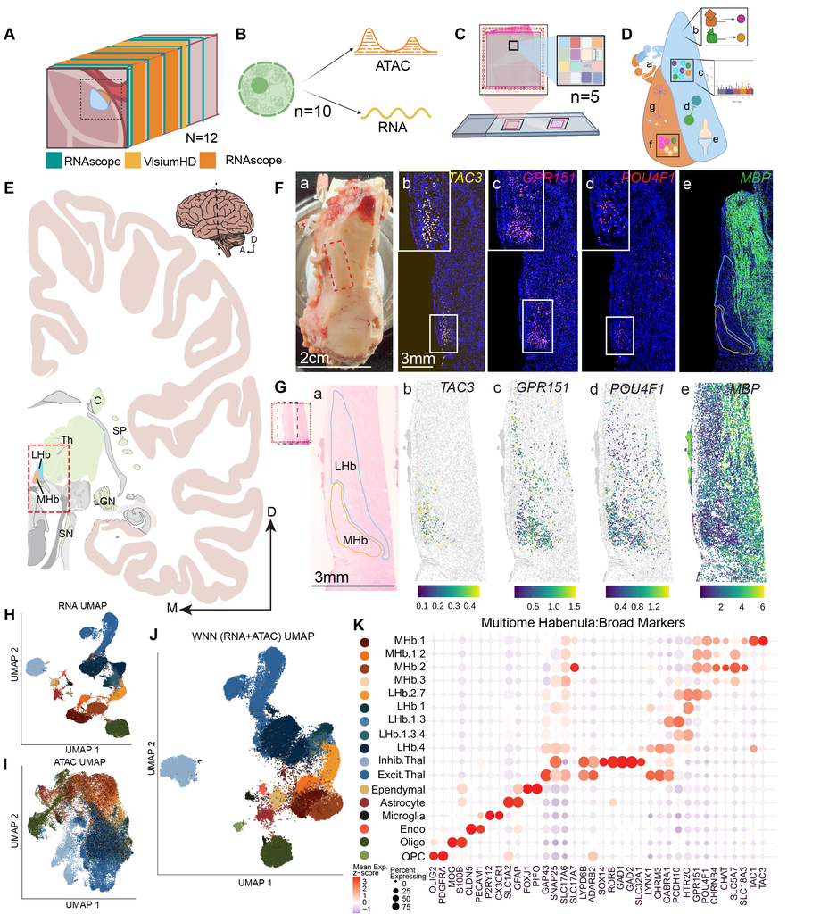

**Multi-omic mapping of the human Hb**. (**A**) A schematic showing the cutting scheme to allow for smFISH/RNAscope, VisiumHD, and snMultiome. The Hb was scored out to minimize thalamic contamination (N=12). (**B**) snMultiome schematic showing that the assay allows for profiling of both the transcriptome and epigenome from the same nuclei (n=10). (**C**) VisiumHD schematic showcasing the subcellular resolution that can be achieved using this spatial transcriptomic technique (n=5). (**D**) A visual representation of the biological questions this study sought to answer. (**D.a.**) Cross talk between the medial and lateral portions of the Hb. (**D.b.**) Transcription factors and which genes are impacted (**D.c.**) Which cell types are at highest risk in disease states. (**D.d.**) Locating inhibitory neurons within the Hb, particularly in the LHb. (**D.e.**) Cell-to-cell communication within the Hb. (**D.f.**) Cell type distribution in the Hb. (**D.g.**) Neuron-glia interactions in the Hb. (**E**) Brain slab illustration that depicts the landmark structures used during dissection (C - caudate, SP - segmented putamen, LGN - lateral geniculate nucleus, SN - substantial nigra, Th - thalamus) and the location of the LHb and MHb and an approximation of the brain blocks that were dissected out. Medial (M), dorsal (D), and anterior (A) directions are shown by the respective arrows. (**F**) A brain block that contained Hb, confirmed by RNAscope. (**F.a.**) Brain block with the Hb demarcated in a red dashed line. (**F.b-e.**) Single channel images of the probe panel used to locate the Hb, TAC3, GPR151, POU4F1, and MBP were used together to identify, generally the Hb (POU4F1) , the MHb (TAC3), LHb (GPR151), and the surrounding white matter (MBP). In (F.e.) the boundaries of the MHb and LHb are drawn. The insets for (E.b-e.) are zoom-ins of the body of the Hb. (**G**) VisiumHD of the same donor shown in E. (**G.a.**) The small image to the left shows the whole 6x6 mm array, with the dashed line showing the section that is shown at a larger scale to the right. The right image in (G.a.) is the eosin staining that was completed during VisiumHD with boundaries of the MHb and LHb that were also in (F.e.). (**G.b-e.**) VisiumHD expression for the same marker genes that were used to confirm the presence of Hb via RNAscope in (E.b-e.). (**H**) A UMAP of the gene expression/RNA data achieved from snMultiome. (**I**) A UMAP of the ATAC data from snMultiome. (**J**) A UMAP of the integrated RNA and ATAC clusters. (**K**) Broad marker genes for the clusters yielded, where the intensity of the color and size of the spot denote the expression of the respective gene.

## Citing Our Work

Please cite our [manuscript](https://doi.org/10.64898/2026.09.30.755667) if you use data from this project.

Below is the citation in [`BibTeX`](http://www.bibtex.org/) format.

[output not shown]

## Interactive Websites

All of these interactive websites are powered by open source software, namely:

- 🔭 [`spatialLIBD`](https://doi.org/10.1186/s12864-022-08601-w)
- 👀 [`iSEE`](https://doi.org/10.12688%2Ff1000research.14966.1)
- 🔍 [`R/Shiny`](https://shiny.posit.co/)

We provide the following interactive websites, organized by dataset with software labeled by emojis:

- 🔍 [snMultiome](https://interactive.libd.org/Habenula_multiome/). Here you can explore the cell-level multiome data, visualize peak-gene-transcription-factor trios computed with a metacell-level object (metacells and trios computed by `TRIPOD`), and view differentially accessible regions (DARs) computed from the snATAC-seq data.
- 👀 [snMultiome, cell-level, RNA only](https://interactive.libd.org/habenula_multiome_cell/). Here you can primarily visualize gene expression of individual cells, by cell type or other discrete variables.
- 🔭 [Visium H&E](https://interactive.libd.org/Habenula_Visium/). Here you can explore the spot-level Visium data, as well as view markers + enrichment statistics for data pseudobulked by preliminary `k = 9` clusters computed with `PRECAST`.
- 👀 [Visium HD pseudobulked by cell type](https://interactive.libd.org/Habenula_Visium_HD_pb/). This app is better suited for quickly exploring how genes globally vary across cell types from the manuscript.
- 🔭 [Visium HD: cell-level](https://interactive.libd.org/Habenula_Visium_HD_Shiny/). This app allows you to spatially explore the cell-level Visium HD data including clusters + cell types, QC variables, and more.

## Data Access

The Zenodo Archive for this project can be found [here](https://doi.org/10.5281/zenodo.23019505). Project data was also uploaded to the [NeMO](https://nemoarchive.org/) and can be found [here](https://assets.nemoarchive.org/col-av55so6) (collection `nemo:col-av55so6`).

The major R objects for each analysis are also available through `spatialLIBD::fetch_data()` as of `spatialLIBD` version `1.25.5`. We provide access to the following R objects, named by the `type` argument provided to `spatialLIBD::fetch_data()`:

- **`habenula_atlas_HD_spe_cell`**: The Visium HD cell-level data as a `SpatialExperiment`.
- **`habenula_atlas_HD_spe_cell_pseudobulk`**: The same data pseudobulked by cell type.
- **`habenula_atlas_visium_spe`**: The Visium H&E spot-level data as a `SpatialExperiment`.
- **`habenula_atlas_visium_spe_pseudobulk`**: The same data pseudobulked by `k = 9` cluster.
- **`habenula_atlas_snMultiome_seurat_cell`**: The snMultiome cell-level data as a `Seurat` object.
- **`habenula_atlas_snMultiome_seurat_metacell`**: The snMultiome metacell-level data as a `Seurat` object.

For example, let’s check out the Visium HD cell-level data:

```r
## Check that you have a recent version of spatialLIBD installed
stopifnot(packageVersion("spatialLIBD") >= "1.25.5")

#   Retrieve the SpatialExperiment object
spe <- spatialLIBD::fetch_data(type = "habenula_atlas_HD_spe_cell")

#   This is a SpatialExperiment object
print(spe)
```

```
#> class: SpatialExperiment
#> dim: 17708 287325
#> metadata(0):
#> assays(2): counts logcounts
#> rownames(17708): ENSG00000187634 ENSG00000188976 ... ENSG00000198695 ENSG00000198727
#> rowData names(7): source type ... gene_type gene_search
#> colnames(287325): 1_H1-W369TJK_D1_9090 2_H1-W369TJK_D1_9090 ... 65739_H1-6FX4YN3_D1_9902
#>   65740_H1-6FX4YN3_D1_9902
#> colData names(18): key sample_id ... cell_type cell_type_colors
#> reducedDimNames(2): PCA UMAP
#> mainExpName: NULL
#> altExpNames(0):
#> spatialCoords names(2) : pxl_col_in_fullres pxl_row_in_fullres
#> imgData names(4): sample_id image_id data scaleFactor
```

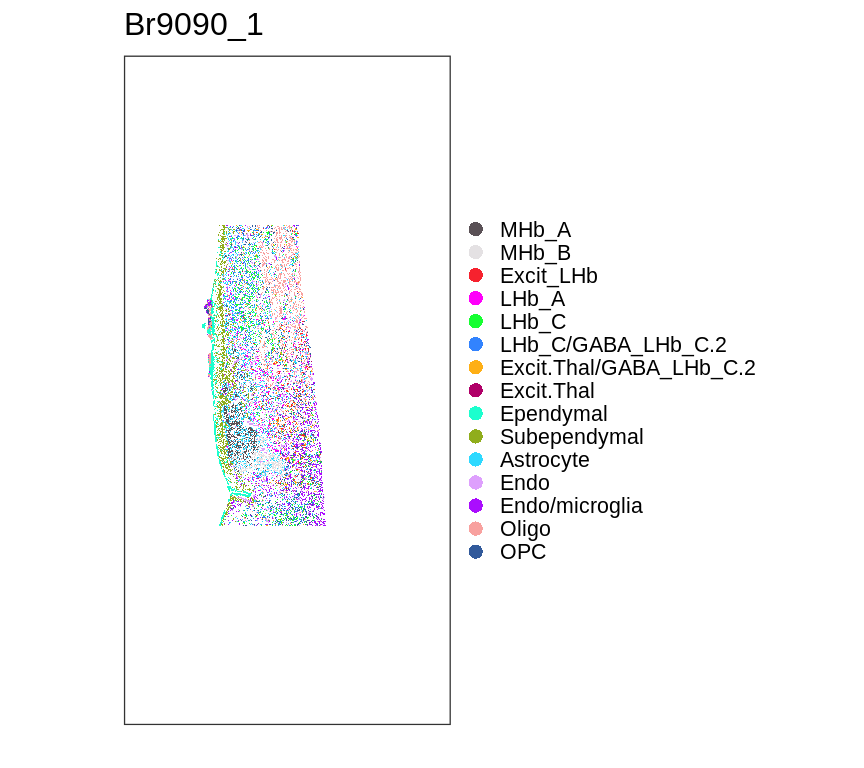

```r
#   Plot the cell types spatially
spatialLIBD::vis_clus(
        spe, sampleid = 'Br9090_1', clustervar = 'cell_type',
        is_stitched = TRUE, spatial = FALSE
    ) +
    #   Make points in legend more visible
    guides(fill = guide_legend(override.aes = list(size = 5)))
```

## Contact

We value public questions, as they allow other users to learn from the answers. If you have any questions, please ask them at LieberInstitute/Hb_multiome/issues and refrain from emailing us. Thank you again for your interest in our work!

## Internal

- JHPCE locations:
  - `/dcs04/lieber/lcolladotor/Habenula_R01_LIBD4270/Hb_multiome`
  - `/dcs04/lieber/lcolladotor/Habenula_R01_LIBD4270/Habenula_Visium`
- Slack channel: [`libd_hb_atlas_paper`](https://jhu-genomics.slack.com/archives/C0AN2UT38G4).

Both GitHub repositories are organized along the [*R/Bioconductor-powered Team Data Science* group guidelines](https://lcolladotor.github.io/bioc_team_ds/organizing-your-work.html#.Yaf9fPHMIdk). They aim to follow the LieberInstitute/template_project structure.